# Prediction Assignment - Practical Machine Learning

Ashutosh Sharma

September 25, 2016

## Introduction

Using devices such as Jawbone Up, Nike FuelBand, and Fitbit it is now possible to collect a large amount of data about personal activity relatively inexpensively. These type of devices are part of the quantified self movement – a group of enthusiasts who take measurements about themselves regularly to improve their health, to find patterns in their behavior, or because they are tech geeks. One thing that people regularly do is quantify how much of a particular activity they do, but they rarely quantify how well they do it. In this project, your goal will be to use data from accelerometers on the belt, forearm, arm, and dumbell of 6 participants. They were asked to perform barbell lifts correctly and incorrectly in 5 different ways. More information is available from the website here: http://groupware.les.inf.puc-rio.br/har (see the section on the Weight Lifting Exercise Dataset).

Data required to perform the prediction is already shared on project assignment page.

The training data for this project are available here:

https://d396qusza40orc.cloudfront.net/predmachlearn/pml-training.csv

The test data are available here:

https://d396qusza40orc.cloudfront.net/predmachlearn/pml-testing.csv

## Load Data

```r
library(caret)
library(randomForest)
```

```r
library(ggplot2)
library(e1071)

# Read csv files

training <- read.csv("/Data/Coursera/practicalmachinelearning/pml-training.csv")
testing <- read.csv("/Data/Coursera/practicalmachinelearning/pml-testing.csv")

str(training)
```

```
## 'data.frame':    19622 obs. of  160 variables:
##  $ X                       : int  1 2 3 4 5 6 7 8 9 10 ...
##  $ user_name               : Factor w/ 6 levels "adelmo","carlitos",..: 2 2 2 2 2 2 2 2 2 2 ...
##  $ raw_timestamp_part_1    : int  1323084231 1323084231 1323084231 1323084232 1323084232 1323084232 1323084232 1323084232 1323084232 1323084232 ...
##  $ raw_timestamp_part_2    : int  788290 808298 820366 120339 196328 304277 368296 440390 484323 484434 ...
##  $ cvtd_timestamp          : Factor w/ 20 levels "02/12/2011 13:32",..: 9 9 9 9 9 9 9 9 9 9 ...
##  $ new_window              : Factor w/ 2 levels "no","yes": 1 1 1 1 1 1 1 1 1 1 ...
##  $ num_window              : int  11 11 11 12 12 12 12 12 12 12 ...
##  $ roll_belt               : num  1.41 1.41 1.42 1.48 1.48 1.45 1.42 1.42 1.43 1.45 ...
##  $ pitch_belt              : num  8.07 8.07 8.07 8.05 8.07 8.06 8.09 8.13 8.16 8.17 ...
##  $ yaw_belt                : num  -94.4 -94.4 -94.4 -94.4 -94.4 -94.4 -94.4 -94.4 -94.4 -94.4 ...
##  $ total_accel_belt        : int  3 3 3 3 3 3 3 3 3 3 ...
##  $ kurtosis_roll_belt      : Factor w/ 397 levels "","0.000673",..: 1 1 1 1 1 1 1 1 1 1 ...
##  $ kurtosis_picth_belt     : Factor w/ 317 levels "","0.006078",..: 1 1 1 1 1 1 1 1 1 1 ...
##  $ kurtosis_yaw_belt       : Factor w/ 2 levels "","#DIV/0!": 1 1 1 1 1 1 1 1 1 1 ...
```

[output cut: 86 more lines]

The raw training data has 19622 rows of observations and 160 features. There are many columns with NAs value in it. So, we need to work on to remove columns with NAs value. There are also some columns which seem to be useless need to be removed.

There is one column of target outcome named “classe”.

Let’s clean the data first:

```r
trainclasse <- training$classe

training <- training[, colSums(is.na(training))==0]
testing <- testing[, colSums(is.na(testing))==0]

filtertraincolumn <- grepl("^X|timestamp|window", names(training))
filtertestcolumn <- grepl("^X|timestamp|window", names(testing))

training <- training[,!filtertraincolumn]
testing <- testing[,!filtertestcolumn]

training <- training[,sapply(training, is.numeric)]
testing <- testing[,sapply(testing, is.numeric)]

training$classe <- trainclasse
```

Now, we fit a predictive model for activity recognition using Random Forest algorithm as it select important features and is robust to correlated covariance. We will use default settings of Random forest available in caret package.

```r
intrain<- createDataPartition(y=training$classe, p=.70, list=FALSE)
traindata <- training[intrain,]
testdata <- training[-intrain,]

modRF <- train(classe~., data = traindata, method="rf",trControl=trainControl(method="cv",5), ntree=300)

predictRF <- predict(modRF, testdata)

accuracy <- confusionMatrix(testdata$classe, predictRF)$overall[1]

outofsample <- 1 - as.numeric(confusionMatrix(testdata$classe, predictRF)$overall[1])
```

Here is the plot of model created:

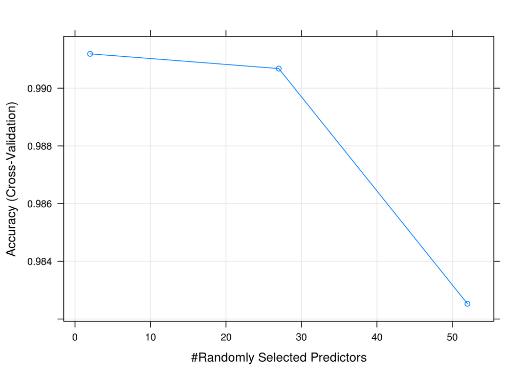

```r
plot(modRF)
```

Plotting the trees vs. error:

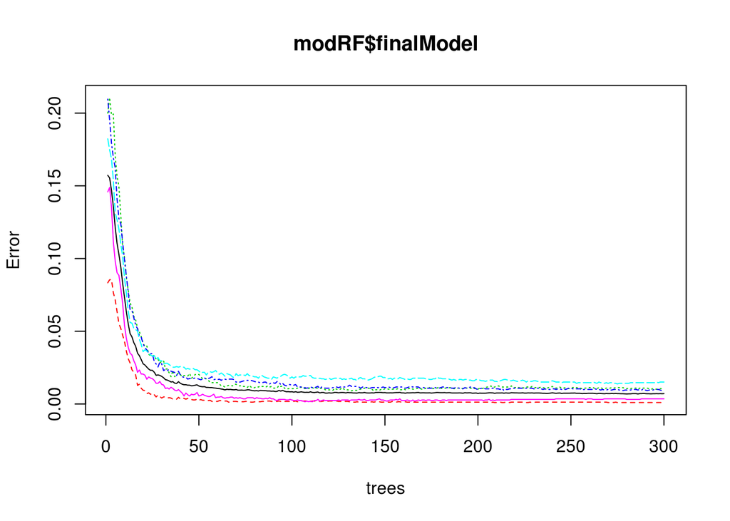

```r
plot(modRF$finalModel)
```

Another plot which represent the predictors importance.

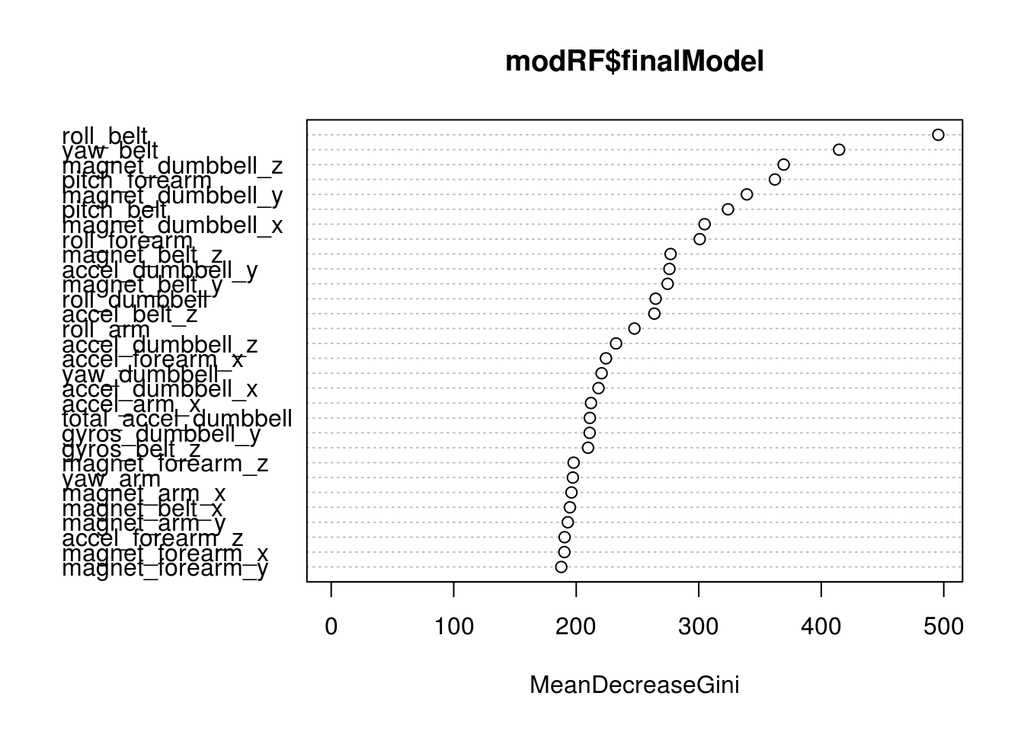

```r
varImpPlot(modRF$finalModel)
```

Let’s predict the testing data provided in assignment using the build Random forest model.

```r
predictTest <- predict(modRF, testing)

predictTest
```

```
##  [1] B A B A A E D B A A B C B A E E A B B B
## Levels: A B C D E
```